# R Notebook

This is an updated version of my original capstone project for the Google Data Analytics certification program. I want to change a few things about my original project:

- execute the SQL queries using R so I can display the results of my queries instead of copy/pasted tables
- write some conclusions to the analysis
- create some visualizations in R and Tableau

Here is the original assignment description from the Google Data Analytics case study:

```
You are a junior data analyst working in the marketing analyst team at Cyclistic, a bike-share company in Chicago. The director of marketing believes the company’s future success depends on maximizing the number of annual memberships. Therefore, your team wants to understand how casual riders and annual members use Cyclistic bikes differently. From these insights, your team will design a new marketing strategy to convert casual riders into annual members. But first, Cyclistic executives must approve your recommendations, so they must be backed up with compelling data insights and professional data visualizations.

- 5,824 bicycles and 692 docking stations across Chicago
- about 30% of users use the bikes to commute to work each day
- single-ride passes, full-day passes, and annual memberships available
- annual members are much more profitable than casual riders
- The company's goal and reason for the analysis: design marketing strategies aimed at converting casual riders into annual members.
```

The data for this project is available [here](https://divvy-tripdata.s3.amazonaws.com/index.html).

### Libraries and getting data

```r
library(tidyverse)
library(scales)
library(DBI)
library(RSQLite)
```

```r
 # initialize database
db <- dbConnect(RSQLite::SQLite(), "")

# import first month's data
df <- read_csv("/Users/taylorparchment/Documents/Analysis/Data/google_data/202205-divvy-tripdata.csv", show_col_types = FALSE)
# convert dataframe's date to character before converting to SQL table
df$started_at <- as.character(df$started_at)
df$ended_at <- as.character(df$ended_at)
# add SQL table
dbWriteTable(db, "bike_data", df)

months <- c("202206", "202207", "202208", "202209", "202210", "202211", "202212", "202301", "202302", "202303", "202304")
# append created SQL table with each month's bike data
for (month in months) {
  filepath <- paste0("/Users/taylorparchment/Documents/Analysis/Data/google_data/", month, "-divvy-tripdata.csv")
  df <- read_csv(filepath, show_col_types = FALSE)
  df$started_at <- as.character(df$started_at)
  df$ended_at <- as.character(df$ended_at)
  dbAppendTable(db, "bike_data", df)
}
```

```r
# check the data
glimpse(dbGetQuery(db, "SELECT * FROM bike_data LIMIT 5"))
```

```
## Rows: 5
## Columns: 13
## $ ride_id            <chr> "EC2DE40644C6B0F4", "1C31AD03897EE385", "1542FBEC83…
## $ rideable_type      <chr> "classic_bike", "classic_bike", "classic_bike", "cl…
## $ started_at         <chr> "2022-05-23 23:06:58", "2022-05-11 08:53:28", "2022…
## $ ended_at           <chr> "2022-05-23 23:40:19", "2022-05-11 09:31:22", "2022…
## $ start_station_name <chr> "Wabash Ave & Grand Ave", "DuSable Lake Shore Dr & …
## $ start_station_id   <chr> "TA1307000117", "13300", "TA1305000032", "TA1305000…
## $ end_station_name   <chr> "Halsted St & Roscoe St", "Field Blvd & South Water…
## $ end_station_id     <chr> "TA1309000025", "15534", "13221", "TA1305000030", "…
## $ start_lat          <dbl> 41.89147, 41.88096, 41.88224, 41.88224, 41.88224
## $ start_lng          <dbl> -87.62676, -87.61674, -87.64107, -87.64107, -87.641…
## $ end_lat            <dbl> 41.94367, 41.88635, 41.90765, 41.88458, 41.88578
## $ end_lng            <dbl> -87.64895, -87.61752, -87.67255, -87.63189, -87.651…
## $ member_casual      <chr> "member", "member", "member", "member", "member"
```

## Data Cleaning

### Latitude and Longitude

First I’ll inspect the longitude and latitude data.

```r
# start long / lat nulls
q <- "
SELECT COUNT(*) as 'Starting Nulls'
FROM bike_data
WHERE start_lat IS NULL
OR start_lng IS NULL
"
dbGetQuery(db, q)
```

| Starting Nulls |
| --- |
| 0 |

```r
# end long / lat nulls
q <- "
SELECT COUNT(*) as 'Ending Nulls'
FROM bike_data
WHERE end_lat IS NULL
OR end_lng IS NULL
"
dbGetQuery(db, q)
```

| Ending Nulls |
| --- |
| 5973 |

While no row is missing its start latitude or longitude, 5973 rows are missing end latitude or longitude. However, since this is a very small percent of the overall data (5973 / 5859061 = 0.00101945), it’s probably safe to delete the missing entries. I’ll use this for calculating ride distance.

```r
q <- "
DELETE FROM bike_data
WHERE end_lat IS NULL
OR end_lng IS NULL
"
dbExecute(db, q)
```

```
## [1] 5973
```

### Stations Data

While the lat / long data is what I’ll need for distance, knowing the popular stations will help us know where we might target ads for casual riders.

```r
q1 <- "
SELECT COUNT(*) as 'Start Station ID Nulls'
FROM bike_data
WHERE start_station_id IS NULL
"

q2 <- "
SELECT COUNT(*) as 'End Station ID Nulls'
FROM bike_data
WHERE end_station_id IS NULL
"

dbGetQuery(db, q1)
```

| Start Station ID Nulls |
| --- |
| 832141 |

```r
dbGetQuery(db, q2)
```

| End Station ID Nulls |
| --- |
| 883829 |

I will manually take a look at the list of unique stations to see if there are any obvious mistakes. One thing I noticed is a lot of stations that begin with “Public Rack”.

```r
q <- "
SELECT COUNT(DISTINCT start_station_name) as 'Public Rack Count'
FROM bike_data
WHERE start_station_name LIKE 'Public Rack%'
"
dbGetQuery(db, q)
```

| Public Rack Count |
| --- |
| 459 |

Do these stations that start with “Public Rack -“ differ from stations that contain just the street name?

```r
# get station names with public rack, and get any existing stations with the same name
# minus "Public Rack -"
q <- "
SELECT DISTINCT start_station_name,
CASE
  WHEN
    TRIM(start_station_name, 'Public Rack -') IN (SELECT DISTINCT start_station_name FROM bike_data)
  THEN TRIM(start_station_name, 'Public Rack -')
  ELSE NULL
END 'Non-Public Name'
FROM bike_data
WHERE start_station_name LIKE 'Public Rack%'
"
station_names <- dbGetQuery(db, q)
head(station_names)
```

|  | start_station_name | Non-Public Name |
| --- | --- | --- |
| 1 | Public Rack - Kenton Ave & Palmer St | Kenton Ave & Palmer St |
| 2 | Public Rack - St Louis Ave & Berteau Ave | St Louis Ave & Berteau Ave |
| 3 | Public Rack - Monticello Ave & Belmont Ave | Monticello Ave & Belmont Ave |
| 4 | Public Rack - California Ave & Cortez St | California Ave & Cortez St |
| 5 | Public Rack - Sacramento Ave & Devon Ave | Sacramento Ave & Devon Ave |
| 6 | Public Rack - California Ave & Ogden Ave | California Ave & Ogden Ave |

```r
# total number of stations which have a "Public Rack - " variant and no station without "Public Rack -"
sum(is.na(station_names))
```

```
## [1] 204
```

About half the stations have both “Public Rack” and non “Public Rack” stations, while the other half has only a public variant. Since I can’t be sure that they refer to the same stations, I will leave the distinction as is.

### Date Data

```r
# check if there are null starting dates
q <- "
SELECT COUNT(*) as 'Starting Date Nulls'
FROM bike_data
WHERE started_at IS NULL
"
dbGetQuery(db, q)
```

| Starting Date Nulls |
| --- |
| 0 |

```r
# check if there are null ending dates
q <- "
SELECT COUNT(*) as 'Ending Date Nulls'
FROM bike_data
WHERE ended_at IS NULL
"
dbGetQuery(db, q)
```

| Ending Date Nulls |
| --- |
| 0 |

```r
# make sure the data falls within the expected range
q <- "SELECT  COUNT(*) as 'Trips Within Data Range'
FROM bike_data
WHERE started_at BETWEEN '2022-05-01 00:00:00' AND '2023-04-30 23:59:59'
"
dbGetQuery(db, q)
```

| Trips Within Data Range |
| --- |
| 5853088 |

```r
# check any rides beyond the range
q <- "
SELECT  COUNT(*) as 'Trips Started Beyond Data Range'
FROM bike_data
WHERE started_at > '2023-04-30 23:59:59'
"

dbGetQuery(db, q)
```

| Trips Started Beyond Data Range |
| --- |
| 0 |

```r
# check any rides before the range
q <- "
SELECT  COUNT(*) as 'Trips Started Before Data Range'
FROM bike_data
WHERE started_at < '022-05-01 00:00:00'
"
dbGetQuery(db, q)
```

| Trips Started Before Data Range |
| --- |
| 0 |

There are no null started_at values and all started_at values are within the timeframe.

```r
q <- "
SELECT  COUNT(*) as 'Ending Outside of Time Range'
FROM bike_data
WHERE ended_at NOT BETWEEN '2022-05-01 00:00:00' AND '2023-04-30 23:59:59'
"
dbGetQuery(db, q)
```

| Ending Outside of Time Range |
| --- |
| 16 |

16 trips ended outside of the time frame, but since all start times were before the end of April 2023, we can assume they started before midnight and finished after midnight 2023-04-30, but I will double check.

```r
q <- "
SELECT started_at, ended_at
FROM bike_data
WHERE ended_at > '2023-04-30 23:59:59'
"
dbGetQuery(db, q)
```

| started_at | ended_at |
| --- | --- |
| 2023-04-30 23:33:28 | 2023-05-01 00:08:42 |
| 2023-04-30 23:43:20 | 2023-05-01 00:02:14 |
| 2023-04-30 07:21:29 | 2023-05-01 07:11:32 |
| 2023-04-30 16:52:28 | 2023-05-01 00:16:44 |
| 2023-04-30 23:51:51 | 2023-05-01 00:06:38 |
| 2023-04-30 23:52:16 | 2023-05-01 00:06:50 |
| 2023-04-30 23:49:26 | 2023-05-01 00:21:55 |
| 2023-04-30 23:48:13 | 2023-05-01 00:05:04 |
| 2023-04-30 23:49:29 | 2023-05-01 00:01:43 |
| 2023-04-30 23:46:41 | 2023-05-01 00:31:22 |

[output cut: 6 more lines]

All of these trips either started late on April 30, or started earlier and were exceptionally long.

```r
q <- "
SELECT COUNT(*) as 'Trips With Later Start than Finish'
FROM bike_data
WHERE started_at > ended_at
"
dbGetQuery(db, q)
```

| Trips With Later Start than Finish |
| --- |
| 103 |

103 trips appear to have a later start time than finish time, which shouldn’t be possible, so I will remove them.

```r
q <- "
DELETE FROM bike_data
WHERE started_at > ended_at
"
dbExecute(db, q)
```

```
## [1] 103
```

Next I’ll check for outliers. I will calculate how long each trip was using SQLite’s julianday function, which will give us a numerical representation of the date that can be used to find the time difference. I’ll look at some of the longest trips.

```r
q <- "
SELECT started_at, ended_at,  ROUND((julianday(ended_at) - julianday(started_at)) * 24, 2) AS 'time_diff_hours'
FROM bike_data
ORDER BY 3 DESC
LIMIT 20
"
dbGetQuery(db, q)
```

| started_at | ended_at | time_diff_hours |
| --- | --- | --- |
| 2022-07-04 18:37:11 | 2022-07-27 00:32:38 | 533.92 |
| 2022-07-10 18:52:42 | 2022-07-18 06:59:55 | 180.12 |
| 2022-05-09 10:58:35 | 2022-05-16 21:41:33 | 178.72 |
| 2022-07-22 13:07:51 | 2022-07-29 11:10:12 | 166.04 |
| 2022-10-24 14:37:54 | 2022-10-30 08:01:42 | 137.40 |
| 2022-06-18 20:25:31 | 2022-06-23 11:38:23 | 111.21 |
| 2022-08-06 11:04:19 | 2022-08-09 19:52:40 | 80.81 |
| 2022-08-26 15:35:28 | 2022-08-28 12:55:24 | 45.33 |
| 2022-07-11 19:59:21 | 2022-07-13 16:08:20 | 44.15 |
| 2023-04-13 17:46:11 | 2023-04-15 08:55:32 | 39.16 |

[output cut: 10 more lines]

There are a lot of unreasonably long trips – I wonder how someone could rent a bike for nearly the entire month of July? One wouldn’t expect this to actually be possible with a bike renting service, so I’d like to investigate this a bit more.

```r
# add a column for trip time
qTimeDiffCol <- "
ALTER TABLE bike_data
ADD COLUMN trip_time_hours
"
dbExecute(db, qTimeDiffCol)
```

```
## [1] 0
```

```r
# set column to difference in hours calculation
qTimeDiffCalc <- "
UPDATE bike_data
SET trip_time_hours = (julianday(ended_at) - julianday(started_at)) * 24
"
dbExecute(db, qTimeDiffCalc)
```

```
## [1] 5852985
```

```r
q <- "
SELECT COUNT(*) as 'Trips Greater than 1 Day'
FROM bike_data
WHERE trip_time_hours > 24
"
dbGetQuery(db, q)
```

| Trips Greater than 1 Day |
| --- |
| 131 |

With this being a very small number of total trips, I think it’s safe to delete all trips that lasted longer than 24 hours.

```r
q <- "
DELETE FROM bike_data
WHERE trip_time_hours > 24
"
dbExecute(db, q)
```

```
## [1] 131
```

I’ll also check outliers on the shorter end of rides.

```r
# check if any start and end times are the same
q <- "
SELECT COUNT(*) as 'Equal Start and End Time'
FROM bike_data
WHERE started_at = ended_at
"
dbGetQuery(db, q)
```

| Equal Start and End Time |
| --- |
| 441 |

These trips were likely incorrectly regiresterd, or had some other issue with the trip. I’ll remove them.

```r
q <- "
DELETE FROM bike_data
WHERE started_at = ended_at
"
dbExecute(db, q)
```

```
## [1] 441
```

I’ll take a look at some of the shortest rides.

```r
q <- "
SELECT ROUND(trip_time_hours * 60 * 60) as Seconds, COUNT(*) as 'Total Trips of This Duration'
FROM bike_data
GROUP BY 1
ORDER BY 1
LIMIT 20
"
dbGetQuery(db, q)
```

| Seconds | Total Trips of This Duration |
| --- | --- |
| 1 | 1002 |
| 2 | 4796 |
| 3 | 4237 |
| 4 | 4165 |
| 5 | 2970 |
| 6 | 3385 |
| 7 | 2929 |
| 8 | 3507 |
| 9 | 3230 |
| 10 | 3352 |

[output cut: 10 more lines]

With over 30,000 trips lasting less than 10 seconds, I’m hesitant to delete them just for being a short time. I can’t know exactly what caused so many people to rent and then immediately dock their bike, but it could say something about casual members who changed their mind, so despite probably not representing real bike trips, I’ll leave them in the data.

### Analysis

#### Seasonal data

```r
# average ride length in minutes for member and casual riders
q <- "
SELECT member_casual,
ROUND(AVG(trip_time_hours * 60), 2) AS 'Average Ride Length (mins)'
FROM bike_data
GROUP BY 1
"
dbGetQuery(db, q)
```

| member_casual | Average Ride Length (mins) |
| --- | --- |
| casual | 21.14 |
| member | 12.19 |

Across all seasons, casual riders generally take longer rides than members.

```r
# assign trips appropriate season based on start month
# then group by member type and season
q <- '
WITH season AS (
SELECT *,
CASE
WHEN  strftime("%m", started_at) BETWEEN "03" AND "05"
THEN "spring"
WHEN strftime("%m", started_at) BETWEEN "06" AND "08"
THEN "summer"
WHEN strftime("%m", started_at) BETWEEN "09" AND "11"
THEN "fall"
ELSE "winter"
END AS season
FROM bike_data
)

SELECT member_casual, season,
ROUND(AVG(trip_time_hours * 60), 2) AS "Average Ride Length (mins)",
COUNT(*) AS "Total Trips"
FROM season
GROUP BY 1, 2
'

dbGetQuery(db, q)
```

| member_casual | season | Average Ride Length (mins) | Total Trips |
| --- | --- | --- | --- |
| casual | fall | 18.64 | 605162 |
| casual | spring | 22.58 | 488630 |
| casual | summer | 22.62 | 1131295 |
| casual | winter | 14.23 | 127603 |
| member | fall | 11.81 | 990954 |
| member | spring | 11.84 | 830020 |
| member | summer | 13.38 | 1244220 |
| member | winter | 10.28 | 434529 |

Across seasons, the number of casual riders and their average ride length varies greatly, peaking in summer and dropping in winter. Members maintain similar ride lengths across seasons and their number of riders fluctuates less greatly, though they also drop in ride count during winter.

We can see that ride length peaks in spring and summer, and the total number of rides in summer is significantly higher, especially for casual members. The same difference exists between seasons for members, but it is less pronounced.

I’d like to take a look at ridership over all months and make a quick visualization for it.

```r
# same as above, but just looking at the months
q <- '
WITH months AS (
SELECT *,
strftime("%m", started_at) as "month"
FROM bike_data
)

SELECT member_casual, month,
ROUND(AVG(trip_time_hours * 60), 2) AS "average_ride_length_mins",
COUNT(*) AS "total_trips"
FROM months
GROUP BY 1, 2
'

months_df <- dbGetQuery(db, q)
```

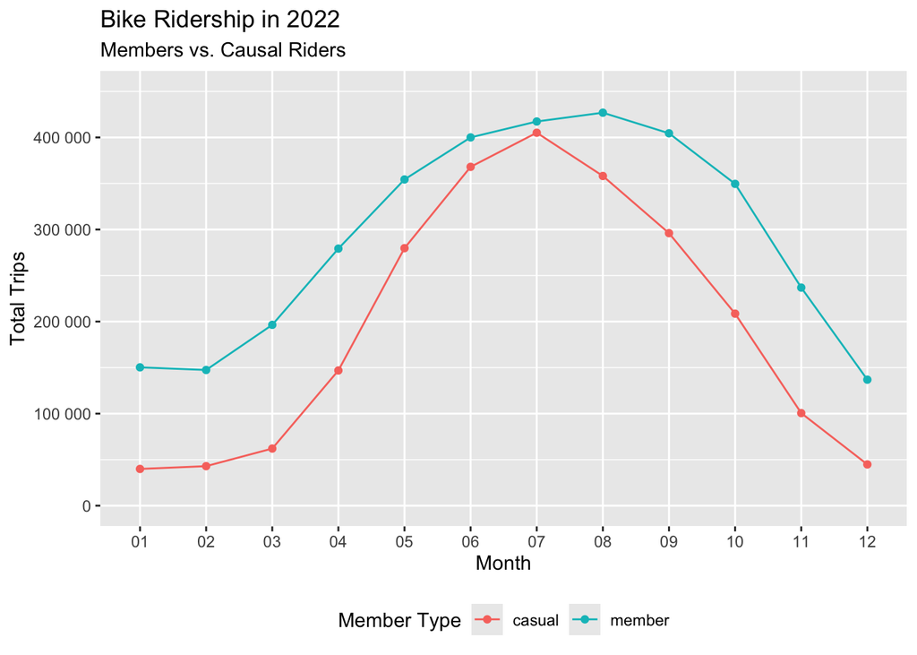

```r
# plot ridership over the year
ggplot(months_df, aes(x = month, y = total_trips, group = member_casual, color = member_casual)) +
  geom_line() +
  geom_point() +
  labs(title = "Bike Ridership in 2022",
       subtitle = "Members vs. Causal Riders",
       y = "Total Trips",
       x = "Month",
       color = "Member Type") +
  theme(legend.position="bottom") +
  scale_y_continuous(labels = label_number()) +
  coord_cartesian(ylim = c(0, 450000))
```

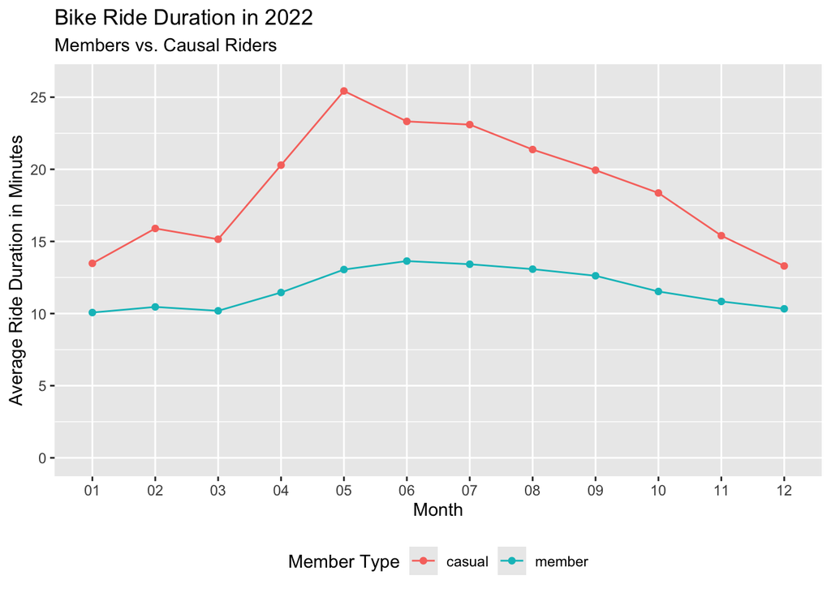

```r
# plot ride length over the year
ggplot(months_df, aes(x = month, y = average_ride_length_mins, group = member_casual, color = member_casual)) +
  geom_line() +
  geom_point() +
  labs(title = "Bike Ride Duration in 2022",
       subtitle = "Members vs. Causal Riders",
       y = "Average Ride Duration in Minutes",
       x = "Month",
       color = "Member Type") +
  theme(legend.position="bottom") +
  coord_cartesian(ylim = c(0, 26)) +
  scale_y_continuous(breaks = seq(0, 30, by = 5))
```

Here we can see a bigger difference between casual riders and members. Members maintain a similar ride time throughout the year, rising by a few minutes in the warmer months. This is presumably because members mostly use the service to get somewhere, and so their trip times remain consistent, and a small number of them ride for recreation in summer.

#### Day of the week

It would also be informative to compare casual riders and members over the course of the week.

```r
q <- "
WITH day_of_week AS(
SELECT *,
CASE CAST (strftime('%w', started_at) AS INTEGER)
  WHEN 0 THEN 'Sunday'
  WHEN 1 THEN 'Monday'
  WHEN 2 THEN 'Tuesday'
  WHEN 3 THEN 'Wednesday'
  WHEN 4 THEN 'Thursday'
  WHEN 5 THEN 'Friday'
  ELSE 'Saturday'
  END AS day_of_week
  FROM bike_data)

SELECT member_casual, day_of_week,
ROUND(AVG(trip_time_hours * 60), 2) AS 'average_ride_length_mins',
COUNT(*) AS 'total_trips'
FROM day_of_week
GROUP BY 1, 2
"

week_df <- dbGetQuery(db, q)
week_df$day_of_week <- factor(week_df$day_of_week, levels = c("Monday", "Tuesday", "Wednesday", "Thursday", "Friday", "Saturday", "Sunday"))
```

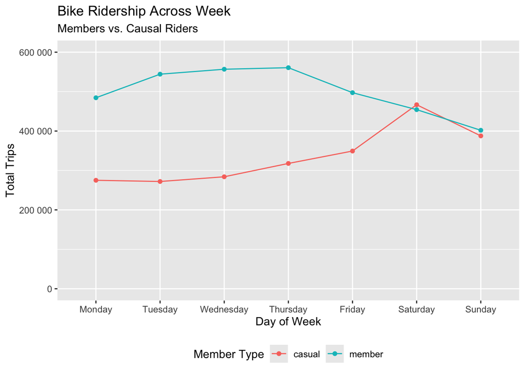

```r
# plot ridership over the week
ggplot(week_df, aes(x = day_of_week, y = total_trips, group = member_casual, color = member_casual)) +
  geom_line() +
  geom_point() +
  labs(title = "Bike Ridership Across Week",
       subtitle = "Members vs. Causal Riders",
       y = "Total Trips",
       x = "Day of Week",
       color = "Member Type") +
  theme(legend.position="bottom") +
  scale_y_continuous(labels = label_number()) +
  coord_cartesian(ylim = c(0, 600000))
```

If members more often ride their bikes to commute, and casual riders more often ride their bikes for recreation, this is exactly what we’d expect – higher member ridership during the week, and lower on weekends, and the reverse for casual members.

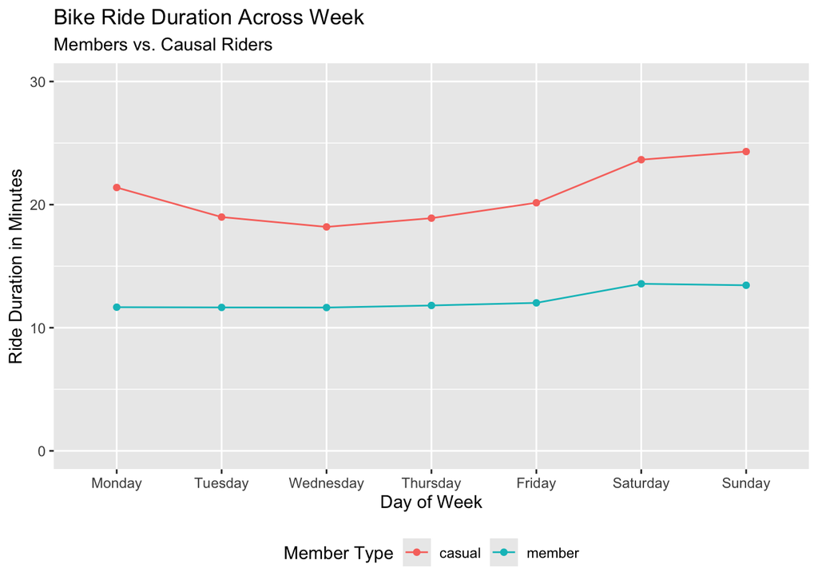

```r
# plot ride length over the week
ggplot(week_df, aes(x = day_of_week, y = average_ride_length_mins, group = member_casual, color = member_casual)) +
  geom_line() +
  geom_point() +
  labs(title = "Bike Ride Duration Across Week",
       subtitle = "Members vs. Causal Riders",
       y = "Ride Duration in Minutes",
       x = "Day of Week",
       color = "Member Type") +
  theme(legend.position="bottom") +
  coord_cartesian(ylim = c(0, 30))
```

We can see that casual riders always ride for longer periods of time than members, but both groups ride longer on the weekend.

#### Time of day

```r
q <- '
WITH time AS (
SELECT *,
strftime("%H", started_at) as "time_hour"
FROM bike_data
)

SELECT member_casual, time_hour,
COUNT(*) AS "total_trips"
FROM time
GROUP BY 1, 2
'

times_df <- dbGetQuery(db, q)
```

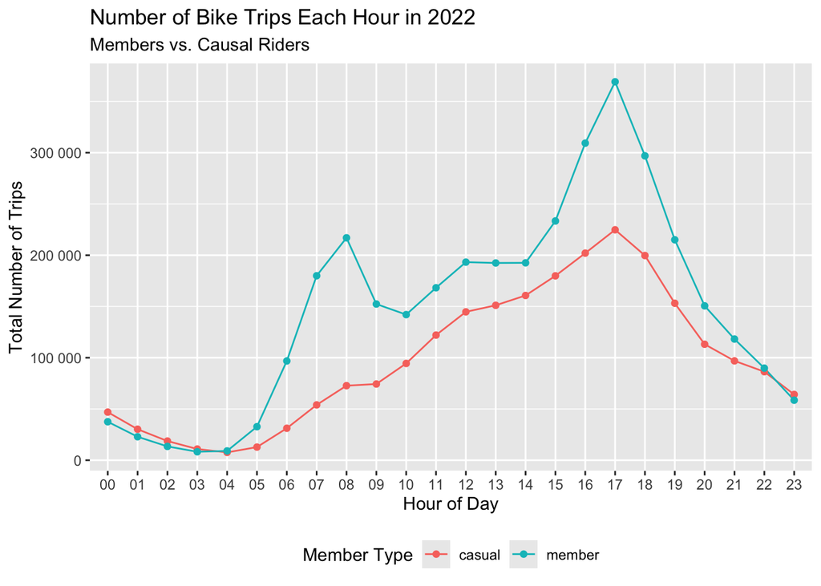

```r
ggplot(times_df, aes(x = time_hour, y = total_trips, group = member_casual, color = member_casual)) +
  geom_line() +
  geom_point() +
  labs(title = "Number of Bike Trips Each Hour in 2022",
       subtitle = "Members vs. Causal Riders",
       y = "Total Number of Trips",
       x = "Hour of Day",
       color = "Member Type") +
  theme(legend.position="bottom") +
  scale_y_continuous(labels = label_number())
```

This visualization really shows what goes on in both groups – at 8am we see a relative peak in member riders who commute. Both groups gradually increase and peak at 5pm, with a very sharp peak in member riders. I think it’s safe to assume this is a combination of riders commuting home, and members who also want to take a leisurely bike ride.

#### Ride distances

```r
qDistanceCol <- "
ALTER TABLE bike_data
ADD COLUMN distance_km
"
dbExecute(db, qDistanceCol)
```

```
## [1] 0
```

```r
qDistanceCalc <- "
UPDATE bike_data
SET distance_km =
ROUND(
6371.0 * 2 * ASIN(
        SQRT(
            POWER(SIN(RADIANS(end_lat - start_lat) / 2), 2) +
            COS(RADIANS(start_lat)) * COS(RADIANS(end_lat)) * POWER(SIN(RADIANS(end_lng - start_lng) / 2), 2)
        )
    ), 3
)
"

dbExecute(db, qDistanceCalc)
```

```
## [1] 5852413
```

This query implements the [Haversine formula](https://www.movable-type.co.uk/scripts/latlong.html) to calculate distance between two lat/long points.

There are limitations to applying this here. Most, if not all bike trips did not take a straight path from start location to end location. Many trips have the same start and end station, suggesting some people take a circular path and return to their start point. The distance we are calculating here is only the distance between the start and end points, not the ride distance. However, I think with the amount of data, this information is still useful, as we can distinguish between effective distance traveled between rider types.

```r
# get highest distance trips
q <- "
SELECT ride_id, distance_km
FROM bike_data
ORDER BY 2 DESC
LIMIT 100
"
dbGetQuery(db, q)
```

| ride_id | distance_km |
| --- | --- |
| 42AF82C53D831251 | 9814.069 |
| E9495F1DC3475D41 | 9813.378 |
| 6AFE1471227BD76F | 9813.072 |
| 75DE33501313D0CE | 9812.918 |
| 7F49424E860E7094 | 9812.916 |
| BB8AA29838266294 | 9812.174 |
| 3B47B333C0D186F0 | 9811.811 |
| 0A6988FE859F4D54 | 9811.511 |
| 353B37694B30396F | 42.272 |
| 5CE2D7C544D25B78 | 37.679 |

[output cut: 90 more lines]

We have several very large outliers looking at this distance, I think it’s safe to assume there’s a problem with these 9000+ km trips.

```r
q <- "
DELETE FROM bike_data
WHERE distance_km > 1000
"
dbExecute(db, q)
```

```
## [1] 8
```

Let’s compare the distances traveled by casual riders and members.

```r
# get average ride distance for each rider type
q <- "
SELECT member_casual, AVG(distance_km)
FROM bike_data
GROUP BY 1
"
dbGetQuery(db, q)
```

| member_casual | AVG(distance_km) |
| --- | --- |
| casual | 2.138162 |
| member | 2.080774 |

Average distances are very close. I would guess both groups take circular and point to point routes.

```r
q <- "
SELECT member_casual, distance_km
FROM bike_data
"
distance_df <- dbGetQuery(db, q)
```

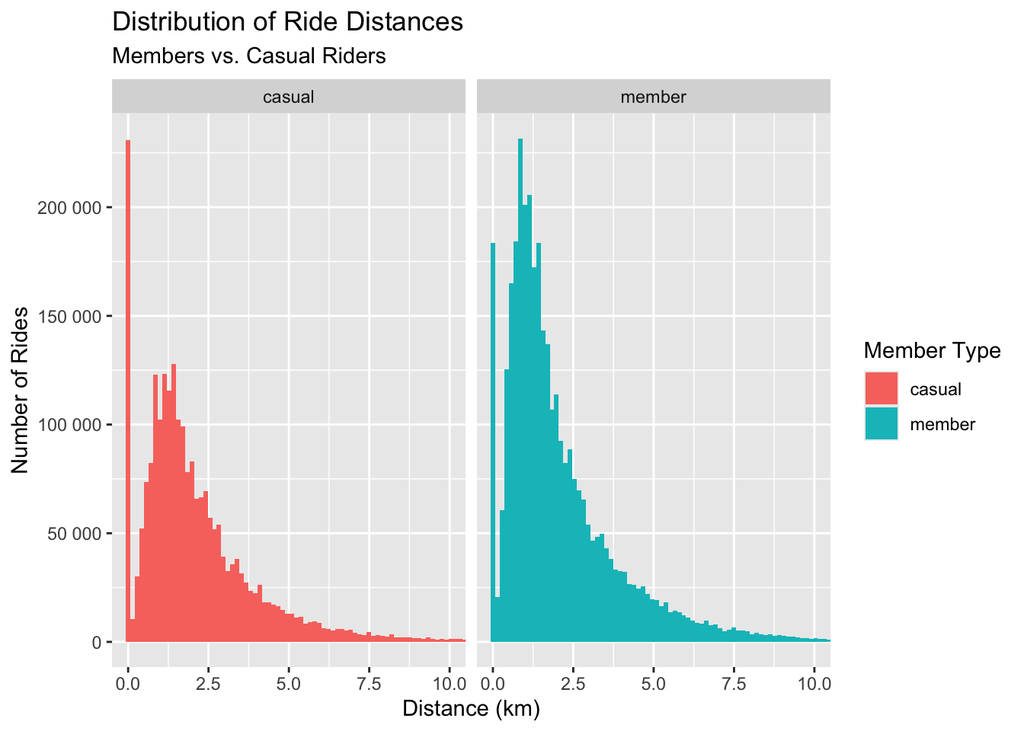

```r
# plot the distribution of distance traveled
ggplot(distance_df, aes(x = distance_km, fill = member_casual)) +
  geom_histogram(bins = 300) +
  scale_y_continuous(labels = label_number()) +
  coord_cartesian(xlim = c(0, 10)) +
  facet_wrap(~member_casual) +
  labs(title = "Distribution of Ride Distances",
       subtitle = "Members vs. Casual Riders",
       y = "Number of Rides",
       x = "Distance (km)",
       fill = "Member Type")
```

```r
  theme(legend.position="bottom")
```

[output not shown]

Though the number of overall rides in the members group is higher, the distributions between the two groups is similar. The only difference is a notably higher number of casual members’ rides end up being 0 kilometers.

```r
# number of riders who return to their starting station
# effectively 0 km distance
q <- "
SELECT member_casual, COUNT(*)
FROM bike_data
WHERE start_station_id = end_station_id
GROUP BY 1
"
dbGetQuery(db, q)
```

| member_casual | COUNT(*) |
| --- | --- |
| casual | 176749 |
| member | 130515 |

#### Popular Stations

I also want to look into the most popular stations. Knowing the stations casual members use the most will let us know what locations would be useful for advertising memberships. First I’ll look at the top casual stations and compare them to members for reference.

```r
q <- "
WITH  popular_stations_casual AS (
SELECT start_station_name, RANK() OVER(ORDER BY COUNT(*) DESC) AS count_rank
FROM bike_data
WHERE member_casual = 'casual' AND start_station_name IS NOT NULL
GROUP BY 1
ORDER BY COUNT(*) DESC
LIMIT 10
)

SELECT popular_stations_casual.count_rank, popular_stations_casual.start_station_name, bike_data.member_casual, COUNT(*) as count
FROM popular_stations_casual
JOIN bike_data
ON popular_stations_casual.start_station_name = bike_data.start_station_name
GROUP BY 2, 3
ORDER BY 1
"

top_casual_stations_df <- dbGetQuery(db, q)
```

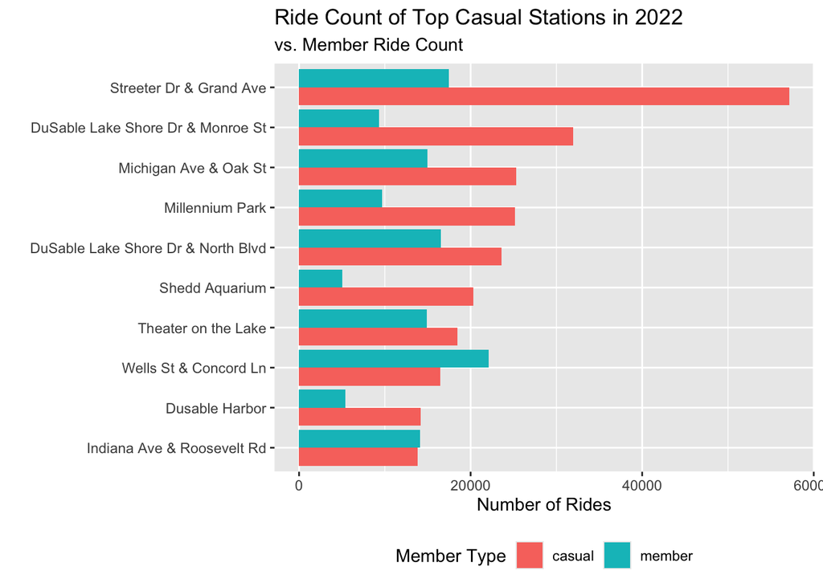

```r
top_casual_stations_df %>%
  mutate(start_station_name = fct_reorder(start_station_name, desc(count_rank))) %>%
  ggplot(aes(x = start_station_name, y = count, fill = member_casual)) +
  geom_col(position = "dodge") +
  labs(title = "Ride Count of Top Casual Stations in 2022",
       subtitle = "vs. Member Ride Count",
       y = "Number of Rides",
       x = "",
       fill = "Member Type") +
  theme(legend.position="bottom") +
  coord_flip()
```

Among the top 10 most popular casual stations, most are used a lot more by casual riders more than members, though there are still several thousand rides by members from each station.

Lastly, I want to look at the most popular routes that members take. I think it would be useful for advertising to know how people are commuting, so that when casual members use those stations, they can be shown how they could ride a bike every day to get somewhere useful.

```r
# create a column with the start and end stations together as 'route' for members
qRouteCol <- "
ALTER TABLE bike_data
ADD COLUMN route
"
dbExecute(db, qRouteCol)
```

```
## [1] 0
```

```r
qRouteCalc <- "
UPDATE bike_data
SET route =
CASE
WHEN member_casual = 'member'
AND start_station_name IS NOT NULL
AND end_station_name IS NOT NULL
AND start_station_name != end_station_name
THEN start_station_name || '_' || end_station_name
END
"
dbExecute(db, qRouteCalc)
```

```
## [1] 5852405
```

```r
q <- "
SELECT route, start_station_name, end_station_name,
start_lat, start_lng, end_lat, end_lng,
COUNT(*) as total_count,
ROUND(AVG(distance_km), 2) as avg_distance_km,
ROUND(AVG(trip_time_hours * 60), 2) as avg_time_mins
FROM bike_data
WHERE route IS NOT NULL
GROUP BY route
ORDER BY COUNT(*) DESC
"
top_routes <- dbGetQuery(db, q)
select(head(top_routes, 10), route, total_count)
```

|  | route | total_count |
| --- | --- | --- |
| 1 | Ellis Ave & 60th St_University Ave & 57th St | 6548 |
| 2 | University Ave & 57th St_Ellis Ave & 60th St | 6179 |
| 3 | Ellis Ave & 60th St_Ellis Ave & 55th St | 5953 |
| 4 | Ellis Ave & 55th St_Ellis Ave & 60th St | 5531 |
| 5 | State St & 33rd St_Calumet Ave & 33rd St | 3980 |
| 6 | Calumet Ave & 33rd St_State St & 33rd St | 3838 |
| 7 | Loomis St & Lexington St_Morgan St & Polk St | 3515 |
| 8 | Morgan St & Polk St_Loomis St & Lexington St | 3342 |
| 9 | University Ave & 57th St_Kimbark Ave & 53rd St | 2696 |
| 10 | Kimbark Ave & 53rd St_University Ave & 57th St | 2409 |

Even though top member routes don’t appear to overlap greatly with the most common stations used by casual riders, when casual riders use these stations, they could be shown a convenient commute route taken by bike members with its corresponding distance and average route time.

## Conclusions

As one might expect, the biggest difference between casual riders and members is definitely the reason for using the bikes. Many **members commute to work** around 8 am, shown by the significant number of rides around that time. However, **casual** riders, using these bikes for recreation, most commonly rent bikes in the **afternoon hours**, peaking at around 5 pm.

There isn’t a significant difference in distance covered by members or casual riders, however casual riders more often **return to their station of origin**, probably only riding for the sake of it and not to go somewhere.

**To convert casual riders into annual members**, it would be good to make it known to them how beneficial these bikes are for commuters. So, when a rider rents a bike at any station which commuters use, they can be shown which locations commuters often commute to from that station, how long it takes them and how far it is.

## Formatting data for Tableau

To demonstrate what sort of information could be shown to riders, I will use the top 10 casual rider stations.

```r
q <- "
SELECT start_station_name, COUNT(*)
FROM bike_data
WHERE member_casual = 'casual' AND start_station_name IS NOT NULL
GROUP BY 1
ORDER BY COUNT(*) DESC
LIMIT 10
"
top_casual_stations_df <- dbGetQuery(db, q)
top_casual_stations_df
```

| start_station_name | COUNT(*) |
| --- | --- |
| Streeter Dr & Grand Ave | 57177 |
| DuSable Lake Shore Dr & Monroe St | 31919 |
| Michigan Ave & Oak St | 25340 |
| Millennium Park | 25140 |
| DuSable Lake Shore Dr & North Blvd | 23628 |
| Shedd Aquarium | 20345 |
| Theater on the Lake | 18451 |
| Wells St & Concord Ln | 16463 |
| Dusable Harbor | 14186 |
| Indiana Ave & Roosevelt Rd | 13832 |

```r
# for any supplied station and list of routes, this function will return the top routes that station appears in (either start or end)
get_top_routes <- function(station, max_results, top_routes) {
  # initialize results to be dataframe of similar structure as routes
  results <- data.frame(matrix(ncol = ncol(top_routes) + 1, nrow = 0))
  colnames(results) <- c("rank", colnames(top_routes))
  for (i in 1:nrow(top_routes)) {
    if (station == top_routes$start_station_name[i]) {
      results <- rbind(results, top_routes[i, , drop = FALSE])
    }
    if (nrow(results) >= max_results) {
      break
    }
  }
  return(results)
}
```

```r
# initialize dataframe with route information for all top casual stations
top_station_routes <- data.frame(matrix(ncol = ncol(top_routes) + 1, nrow = 0))
colnames(top_station_routes) <- c("rank", colnames(top_routes))

# go through top casual stations, get top 5 member routes for each one,
# combine into single dataframe
for (i in 1:nrow(top_casual_stations_df)) {
  station <- top_casual_stations_df$start_station_name[i]
  station_routes <- get_top_routes(station, 5, top_routes)
  station_routes$rank <- i
  top_station_routes <- rbind(top_station_routes, station_routes)
}
```

Lastly, I’ll need to transform this into a format that can be used in Tableau.

```r
# pivot the stations data long to create separate start and end station rows
tableau_data <- pivot_longer(top_station_routes,
                        cols = c(start_station_name, end_station_name),
                        names_to = "origin_destination",
                        values_to = "station")

# set start stations to "origin", end stations to "destination" based on start or end station
tableau_data <- mutate(tableau_data, origin_destination = ifelse(origin_destination == "start_station_name", "origin", "destination"))

# set correct latitude and longitude based on origin_destination
tableau_data <- mutate(tableau_data,
                  latitude = ifelse(origin_destination == "origin", start_lat, end_lat),
                  longitude = ifelse(origin_destination == "origin", start_lng, end_lng))




# Reorder the columns as desired
tableau_data <- tableau_data[, c("rank", "origin_destination", "station", "route", "latitude", "longitude", "avg_distance_km", "avg_time_mins")]

head(tableau_data)
```

| rank | origin_destination | station | route | latitude | longitude | avg_distance_km | avg_time_mins |
| --- | --- | --- | --- | --- | --- | --- | --- |
| 1 | origin | Streeter Dr & Grand Ave | Streeter Dr & Grand Ave_DuSable Lake Shore Dr & North Blvd | 41.89228 | -87.61204 | 2.48 | 18.82 |
| 1 | destination | DuSable Lake Shore Dr & North Blvd | Streeter Dr & Grand Ave_DuSable Lake Shore Dr & North Blvd | 41.91172 | -87.62680 | 2.48 | 18.82 |
| 1 | origin | Streeter Dr & Grand Ave | Streeter Dr & Grand Ave_Theater on the Lake | 41.89228 | -87.61204 | 4.09 | 24.09 |
| 1 | destination | Theater on the Lake | Streeter Dr & Grand Ave_Theater on the Lake | 41.92628 | -87.63083 | 4.09 | 24.09 |
| 1 | origin | Streeter Dr & Grand Ave | Streeter Dr & Grand Ave_DuSable Lake Shore Dr & Monroe St | 41.89228 | -87.61204 | 1.32 | 17.16 |
| 1 | destination | DuSable Lake Shore Dr & Monroe St | Streeter Dr & Grand Ave_DuSable Lake Shore Dr & Monroe St | 41.88096 | -87.61674 | 1.32 | 17.16 |

```r
# write_csv(tableau_data, "tableau_data.csv")
```

View the visualization [here](https://public.tableau.com/app/profile/john.parchment/viz/GoogleBikeShareAnalysis/Dashboard1?publish=yes).